# EEG Onset Simulation: Multi-Electrode Estimation and Method Comparison

Author

Maram

```r
# packages
library(tidyverse)     # data wrangling and plotting
library(changepoint)   # change point detection

# code and data from Rousselet (2025)
source("code/eeg_noise.R")              # noise generator
source("code/erp_template.R")           # signal template
meanpower <- scan("code/meanpower.txt") # noise power spectrum

# figures and tables
knitr::opts_chunk$set(fig.width = 8, fig.height = 5)
options(knitr.kable.NA = "")            # blank, not NA, for cells that do not apply
source("code/theme_dark_bw.R")          # strict black-and-white plotting theme

# reproducibility
set.seed(26)
```

# 1 Quick checks

The simulation depends on the signal matrix, the true onset, the time axis and the noise power spectrum, all of which are rebuilt below and checked against known values before any onset is estimated.

The signal template, its 160 ms onset and the 50 trials per condition follow Rousselet (2025), so the results remain comparable with the original simulation. Trial count also governs the measurement error of an averaged ERP, since noise in the averaged waveform is the main source of that error and averaging more trials reduces it (Luck, 2014), and is varied in a later section for that reason.

The nine weights, 0, 0, 0.3, 0.75, 1, 0.75, 0.3, 0, 0, distribute a single signal across the electrode array, strongest at the centre and absent at the two outermost sites on each side. Component amplitude varies across recording sites, so an effect that is clear at one electrode may be undetectable at another (Luck, 2014).

```r
# the pieces the simulation needs
Nt   <- 50                                    # default trials per condition
w    <- c(0, 0, 0.3, 0.75, 1, 0.75, 0.3, 0, 0)
elec <- 1:9
signal_9 <- outer(temp2, w)                   # 251 time points x 9 electrodes
colnames(signal_9) <- paste0("E", elec)

# quick checks
dim(signal_9)        # expect 251 x 9
```

```
[1] 251   9
```

```r
true_onset           # expect 160 ms
```

```
[1] 160
```

```r
range(Xf)            # expect 0 to 500 ms
```

```
[1]   0 500
```

```r
length(meanpower)    # noise power spectrum loaded
```

```
[1] 125
```

Estimation proceeds only once all four match, since a departure would indicate a fault in the setup rather than in the methods under comparison.

# 2 The onset method

## 2.1 Description

Each simulated experiment contains two conditions at every electrode: condition A, noise only, and condition B, signal plus noise, with 50 trials each. A Welch t-test then compares them at each electrode and time point, and the t value is squared, giving one squared-t curve per electrode that stays near zero while the conditions agree and rises once they diverge. Squaring discards the sign, since only the magnitude of the difference is at issue.

Seven methods read an onset from those curves. Where a correction for multiple comparisons is applied, it spans the whole electrode-by-time search space; the methods differ in whether an onset is read at every electrode or from a single combined curve.

- FDR BH: Benjamini-Hochberg false discovery rate across all nine electrodes and all time points jointly, then the first significant point at each electrode.
- FDR BY: the Benjamini-Yekutieli version, valid under arbitrary dependence and more conservative, applied the same way.
- MAX across electrodes: a single familywise threshold from a permutation test, then the first crossing at each electrode.
- change point at every electrode: the first sustained shift in each squared-t curve, by binary segmentation based on recursive hierarchical splitting (Edwards & Cavalli-Sforza, 1965; Scott & Knott, 1974), as implemented in the `changepoint` package (Killick & Eckley, 2014). No correction is applied.
- change point restricted to significant electrodes: the same onsets, retained only at electrodes whose squared-t crosses the MAX threshold, and missing elsewhere.
- MAX on a virtual electrode: the same threshold applied to the virtual electrode, the maximum squared t across electrodes at each time point.
- change point on the virtual electrode: change point applied to that same curve. No correction is applied. This pairing is proposed as an extension in Rousselet (2025).

The first five leave one onset per electrode, so they need a summary across electrodes; that summary is computed outside the simulation loop and is the subject of the next section. The last two yield a single onset, so no across-electrode summary applies to them.

## 2.2 Justification

Correcting each electrode in isolation would control the error rate at that electrode but not across the experiment, where all of them are tested at once. Onsets are nevertheless stored at every electrode, which keeps the group onset an offline reporting choice and preserves the individual electrodes as a sanity check.

The summary across electrodes covers all nine, not the five carrying signal. Which electrodes carry an effect is precisely what an experiment sets out to discover, so a method permitted to know it in advance is not being tested. The consequence is that a method without error control will report onsets at electrodes where there is no effect to find, and one such early value fixes the group minimum. This is a property of the method, and the reason for reporting quantiles alongside the minimum.

Change point is included alongside the mass-univariate methods because the two define an onset differently: the first significant time point can be reached by a single chance excursion, whereas a change point requires a sustained shift. Which definition recovers the truth more closely is what the simulation is for. Change point carries no notion of whether an effect exists at all, however, and will locate a shift in whatever curve it receives, including one containing only noise. The restricted variant addresses this by the division of labour proposed in Rousselet (2025), where a corrected mass-univariate test, MAX in particular, establishes the presence of an effect and change point then locates its start. Selection and estimation draw on the same data. Selective analysis of this kind is justified only where the results statistic is independent of the selection criterion under the null hypothesis; otherwise it distorts the estimates and invalidates the inference, and the distortion tends to make results agree with the criterion used to select them (Kriegeskorte et al., 2009). That condition does not hold here, since the MAX threshold and the change point are both read from the same squared-t curve. The selection is at least explicit and reproducible, but it is not independent.

The virtual electrode takes the maximum statistic across electrodes (Jaworska et al., 2020, as cited in Rousselet, 2025), reducing the spatial dimension to one curve that tracks where the strongest effect lies at each moment.

The MAX threshold comes from a permutation test in which trial labels are reshuffled, the squared t recomputed, and the maximum over the whole electrode-by-time space retained; the 95th percentile of 1000 such maxima becomes the threshold. One shuffle is applied across all electrodes and time points together, because electrodes are correlated in both noise and signal and the resampling must preserve that structure. Trials are the exchangeable unit, and are independent here by construction. Reading the first crossing of this threshold is equivalent to reading the first p-value below .05, since a threshold of this kind is an inverted test, so per-point p-values are not computed.

## 2.3 Code

```r
nperm       <- 1000     # permutations for the MAX threshold
cpd_penalty <- "MBIC"   # change point penalty
sig_level   <- 0.05     # significance level for the FDR methods

# variance of each row (time point) of a time x trials matrix
rowVars <- function(X){
  n <- ncol(X); m <- rowMeans(X)
  (rowSums(X^2) - n * m^2) / (n - 1)
}

# Welch squared-t and p at every time point, one electrode
welch_t2p <- function(Ae, Be){
  nA <- ncol(Ae); nB <- ncol(Be)
  mA <- rowMeans(Ae); mB <- rowMeans(Be)
  vA <- rowVars(Ae);  vB <- rowVars(Be)
  se2  <- vA / nA + vB / nB
  tval <- (mB - mA) / sqrt(se2)
  df   <- se2^2 / ((vA / nA)^2 / (nA - 1) + (vB / nB)^2 / (nB - 1))
  list(t2 = tval^2, p = 2 * pt(-abs(tval), df))
}

# helpers that turn a time course into an onset in ms
cp_onset <- function(series, penalty = cpd_penalty){
  tryCatch({
    cp  <- cpt.meanvar(series, method = "BinSeg", Q = 2, penalty = penalty, minseglen = 2)
    pts <- cpts(cp)
    # earliest of the two change points, whatever order cpts() returns them in
    if(length(pts) == 0) NA_real_ else Xf[min(pts)]
  }, error = function(e) NA_real_)
}
first_cross <- function(series, thr){
  s <- which(series > thr); if(length(s) == 0) NA_real_ else Xf[s[1]]
}
first_sig <- function(pcol, level = sig_level){
  s <- which(pcol < level); if(length(s) == 0) NA_real_ else Xf[s[1]]
}

# summaries across electrodes
safe_min <- function(x){ x <- x[!is.na(x)]; if(length(x) == 0) NA_real_ else min(x) }
safe_quantile <- function(x, p){
  x <- x[!is.na(x)]; if(length(x) == 0) NA_real_ else quantile(x, p, names = FALSE)
}

# group onset per method, from the saved per-electrode onsets
group_from_perelec <- function(perelec, virtual){
  bind_rows(
    perelec |>
      group_by(method) |>
      summarise(min    = safe_min(onset),
                q10    = safe_quantile(onset, 0.10),
                q25    = safe_quantile(onset, 0.25),
                median = safe_quantile(onset, 0.50),
                .groups = "drop") |>
      pivot_longer(-method, names_to = "summary", values_to = "onset"),
    virtual |>
      transmute(method, summary = "single", onset)
  )
}
```

```r
# one experiment: per-electrode onsets, plus one onset per virtual method
experiment_onsets <- function(Nt = 50){

  # trials: time x trial x electrode
  A <- array(0, dim = c(Nf, Nt, 9))   # noise only
  B <- array(0, dim = c(Nf, Nt, 9))   # signal + noise
  for(e in 1:9){
    A[, , e] <- replicate(Nt, eeg_noise(Nf, 500, 1, meanpower))
    B[, , e] <- replicate(Nt, signal_9[, e] + eeg_noise(Nf, 500, 1, meanpower))
  }

  # observed squared-t and p, per electrode and time
  T2obs <- matrix(NA_real_, Nf, 9)
  Pobs  <- matrix(NA_real_, Nf, 9)
  for(e in 1:9){
    tp <- welch_t2p(A[, , e], B[, , e])
    T2obs[, e] <- tp$t2
    Pobs[, e]  <- tp$p
  }
  vobs <- apply(T2obs, 1, max)        # virtual electrode: max squared-t across electrodes

  # permutation null for the MAX threshold: one shared shuffle of the 2*Nt trial
  # labels, applied to every electrode, so the structure across electrodes is kept
  pool <- lapply(1:9, function(e) cbind(A[, , e], B[, , e]))   # time x 2Nt, built once

  null_max <- numeric(nperm)
  for(b in 1:nperm){
    perm <- sample(2 * Nt)
    g1 <- perm[1:Nt]; g2 <- perm[(Nt + 1):(2 * Nt)]
    t2p <- matrix(NA_real_, Nf, 9)
    for(e in 1:9){
      t2p[, e] <- welch_t2p(pool[[e]][, g1, drop = FALSE],
                            pool[[e]][, g2, drop = FALSE])$t2
    }
    null_max[b] <- max(t2p)                              # max across the whole space
  }
  thr <- quantile(null_max, 0.95, names = FALSE)

  # FDR across the whole electrode-by-time search space
  bh <- matrix(p.adjust(as.vector(Pobs), "BH"), nrow = Nf)
  by <- matrix(p.adjust(as.vector(Pobs), "BY"), nrow = Nf)

  # change point everywhere, then the same onsets masked by MAX significance
  cpd_all  <- sapply(1:9, function(e) cp_onset(T2obs[, e]))
  elec_sig <- apply(T2obs, 2, max) > thr
  cpd_sig  <- if_else(elec_sig, cpd_all, NA_real_)

  # onsets at all nine electrodes, no selection on weight
  perelec <- tibble(
    electrode = rep(paste0("E", elec), 5),
    weight    = rep(w, 5),
    method    = rep(c("FDR BH", "FDR BY", "MAX across",
                      "CPD per electrode", "CPD if MAX significant"), each = 9),
    onset     = c(sapply(1:9, function(e) first_sig(bh[, e])),
                  sapply(1:9, function(e) first_sig(by[, e])),
                  sapply(1:9, function(e) first_cross(T2obs[, e], thr)),
                  cpd_all,
                  cpd_sig)
  )

  # virtual electrode methods: one onset each
  virtual <- tibble(
    method = c("MAX virtual", "CPD virtual"),
    onset  = c(first_cross(vobs, thr),
               cp_onset(vobs))
  )

  # raw onsets only: all summarising happens offline. Nt travels with the onsets
  # so that runs at different sample sizes can be separated afterwards.
  list(perelec = mutate(perelec, Nt = Nt),
       virtual = mutate(virtual, Nt = Nt))
}
```

## 2.4 Table

```r
set.seed(1)
once <- experiment_onsets()
group_from_perelec(once$perelec, once$virtual) |>
  pivot_wider(names_from = summary, values_from = onset) |>
  knitr::kable()
```

Table 1: Group onset (ms) for the seven methods, run once. For the five electrode-wise methods the summaries are taken across all nine electrodes; the two virtual-electrode methods give a single onset, shown in the `single` column.

| method | min | q10 | q25 | median | single |
| --- | --- | --- | --- | --- | --- |
| CPD if MAX significant | 196 | 198.0 | 201 | 206 |  |
| CPD per electrode | 122 | 142.8 | 188 | 206 |  |
| FDR BH | 210 | 213.0 | 217 | 225 |  |
| FDR BY | 220 | 220.4 | 221 | 222 |  |
| MAX across | 220 | 220.8 | 222 | 224 |  |
| MAX virtual |  |  |  |  | 220 |
| CPD virtual |  |  |  |  | 206 |

## 2.5 Observations

On this run the unrestricted change-point minimum falls at 122 ms, 38 ms before the true onset, while the same method restricted to the electrodes that the MAX test declares significant gives 196 ms. MAX across and MAX virtual both give 220 ms, as they must. The gap between the minimum and the median is widest for unrestricted change point, 122 against 206 ms, and narrowest for Benjamini-Yekutieli, at 220 against 222 ms. A single run is noisy regardless, so the experiment is repeated below.

# 3 Saved simulation results

## 3.1 Description

All reported Monte Carlo results are loaded from saved `.RData` files. The simulation-generating functions above are retained for reproducibility, but they are not called during rendering. This keeps the analysis tied to the completed simulation runs rather than generating new results each time the notebook is rendered.

Three simulation datasets were generated independently. The first contains 1,000 iterations with 50 trials per condition and is retained for the electrode-wise diagnostic. The second contains 10,000 iterations with 50 trials per condition and is used for the primary method comparison. The third contains 1,000 iterations at each of 25, 50, 75 and 100 trials per condition and is used for the trial-number sensitivity analysis.

## 3.2 Justification

The larger 10,000-iteration run provides the primary comparison because Monte Carlo summaries are more stable when they are based on more completed simulations. The two 1,000-iteration datasets answer different secondary questions and were generated separately from the main run: one retains the original 50-trial design for electrode-level diagnostics, while the other varies trial number to assess sensitivity to sample size.

## 3.3 Code

The saved outputs are loaded into separate environments so that objects with the same names cannot overwrite one another during rendering.

```r
resolve_file <- function(...){
  paths <- c(...)
  hit <- paths[file.exists(paths)]
  if(length(hit) == 0) stop("Required saved result file not found: ",
                            paste(paths, collapse = " | "))
  hit[1]
}

MAIN_FILE <- resolve_file("data/simres_n50.RData", "simres_n50.RData")
DIAG_FILE <- resolve_file("data/simres.RData", "simres.RData")
SIZE_FILE <- resolve_file("data/simres_1000_sizes.RData", "simres_1000_sizes.RData")

load_result_pair <- function(path){
  env <- new.env(parent = emptyenv())
  load(path, envir = env)
  obj <- as.list(env)

  pick <- function(required, forbidden = character()){
    hit <- obj[vapply(obj, function(x)
      is.data.frame(x) &&
      all(required %in% names(x)) &&
      !any(forbidden %in% names(x)), logical(1))]
    if(length(hit) != 1) stop("Could not identify saved table in ", path)
    hit[[1]]
  }

  pe <- if("perelec_all" %in% names(obj)) obj[["perelec_all"]] else
    pick(c("iter", "electrode", "weight", "method", "onset"))
  vi <- if("virtual_all" %in% names(obj)) obj[["virtual_all"]] else
    pick(c("iter", "method", "onset"), c("electrode", "weight"))

  list(perelec = as_tibble(pe), virtual = as_tibble(vi))
}

main_saved <- load_result_pair(MAIN_FILE)
diag_saved <- load_result_pair(DIAG_FILE)
size_saved <- load_result_pair(SIZE_FILE)

main_pe <- main_saved$perelec
main_vi <- main_saved$virtual
diag_pe <- diag_saved$perelec
diag_vi <- diag_saved$virtual
size_pe <- size_saved$perelec
size_vi <- size_saved$virtual

# Older fixed-50-trial files may not store Nt explicitly.
if(!"Nt" %in% names(main_pe)) main_pe$Nt <- 50
if(!"Nt" %in% names(main_vi)) main_vi$Nt <- 50
if(!"Nt" %in% names(diag_pe)) diag_pe$Nt <- 50
if(!"Nt" %in% names(diag_vi)) diag_vi$Nt <- 50

# Basic checks on the three independently generated saved outputs.
stopifnot(max(main_pe$iter, na.rm = TRUE) == 10000)
stopifnot(max(diag_pe$iter, na.rm = TRUE) == 1000)
stopifnot(identical(as.numeric(sort(unique(size_pe$Nt))), c(25, 50, 75, 100)))
```

```r
# Convert saved electrode-wise onsets into montage-level summaries.
make_group_onsets <- function(pe, vi, include_Nt = FALSE){
  groups <- if(include_Nt) c("Nt", "iter", "method") else c("iter", "method")

  pe_g <- pe |>
    group_by(across(all_of(groups))) |>
    summarise(min    = safe_min(onset),
              q10    = safe_quantile(onset, 0.10),
              q25    = safe_quantile(onset, 0.25),
              median = safe_quantile(onset, 0.50),
              .groups = "drop") |>
    pivot_longer(c(min, q10, q25, median),
                 names_to = "summary", values_to = "onset")

  vi_g <- if(include_Nt)
    vi |> transmute(Nt, iter, method, summary = "single", onset)
  else
    vi |> transmute(iter, method, summary = "single", onset)

  bind_rows(pe_g, vi_g)
}

group_main <- make_group_onsets(main_pe, main_vi, include_Nt = FALSE) |> mutate(Nt = 50)
group_size <- make_group_onsets(size_pe, size_vi, include_Nt = TRUE)

# Names retained below for the primary 10,000-run analysis.
group_onset <- group_main
perelec_all <- main_pe
virtual_all <- main_vi
```

# 4 Summarising the onset distributions

## 4.1 Description

Each electrode-wise method leaves one onset per electrode, which has to be reduced to a single value before it can be scored against the truth. Four summaries are computed across electrodes: the minimum, the 10th and 25th percentiles, and the median. Each method-and-summary pair is then treated as a separate strategy and summarised across the 10,000-run primary simulation, with the per-electrode onsets retained as a secondary check.

## 4.2 Justification

The choice of summary belongs to the method rather than to its presentation. The minimum corresponds to the question posed, the earliest significant effect across electrodes, but it is also the summary most exposed to a single false onset, since one early error anywhere among the nine fixes the group value. The median describes where a typical electrode places the onset and is correspondingly robust, at the price of discarding the earliest evidence. The intermediate quantiles are included because the best answer may fall between the two, and because the choice is settled by calibration against a known truth rather than by argument (Rousselet, 2025). Applying the same four summaries to every method keeps the comparison fair; reporting the median for change point alone would judge the FDR methods on their most fragile summary and change point on its most robust.

Across runs the median is used rather than the mean, because onset distributions are skewed (Rousselet & Wilcox, 2020, as cited in Rousselet, 2025). Bias relative to 160 ms is reported alongside spread, since accuracy and precision can diverge, together with the number of runs in which a strategy returned no onset at all: a strategy that is accurate when it fires but frequently silent is not usable.

Two measures of error are given because they answer different questions. Bias is the distance of the median estimate from the truth, so errors in opposite directions cancel: a strategy that is 100 ms early as often as it is 100 ms late has no bias at all. The mean absolute error does not allow that cancellation, and is the measure used by Rousselet (2025), which keeps the results directly comparable with that paper. The standard deviation is retained alongside both, although it is a dispersion measure built on the mean and therefore the least suited of the three to a skewed distribution.

## 4.3 Code

```r
elecwise_methods <- c("FDR BH", "FDR BY", "MAX across",
                      "CPD per electrode", "CPD if MAX significant")
virtual_methods  <- c("MAX virtual", "CPD virtual")
summary_order    <- c("min", "q10", "q25", "median")

# one label per method-and-summary pair, summaries of a method kept adjacent
label_levels <- c(paste0(rep(elecwise_methods, each = length(summary_order)),
                         " (", summary_order, ")"),
                  virtual_methods)

group_onset <- group_onset |>
  mutate(method  = factor(method, levels = c(elecwise_methods, virtual_methods)),
         summary = factor(summary, levels = c(summary_order, "single")),
         label   = factor(if_else(summary == "single",
                                  as.character(method),
                                  paste0(method, " (", summary, ")")),
                          levels = label_levels))

# each strategy across the runs: location, spread, bias, and failures to fire
method_summary <- group_onset |>
  group_by(Nt, label) |>
  summarise(median_onset = median(onset, na.rm = TRUE),
            sd_onset     = round(sd(onset, na.rm = TRUE), 1),
            mae          = round(mean(abs(onset - true_onset), na.rm = TRUE), 1),
            underestimation = round(100 * mean(onset < true_onset, na.rm = TRUE), 1),
            n_missing    = sum(is.na(onset)),
            .groups = "drop") |>
  mutate(bias = round(median_onset - true_onset, 1), .after = sd_onset)

# per-electrode check; zero-weight electrodes give a false-alarm rate
summary_em <- diag_pe |>
  group_by(Nt, electrode, weight, method) |>
  summarise(median_onset   = median(onset, na.rm = TRUE),
            detection_rate = round(mean(!is.na(onset)), 2),
            .groups = "drop")
```

### 4.3.1 Primary-strategy MAE and Monte Carlo error

The full strategy table below remains the main descriptive summary from Version 1. In addition, the six primary strategies used in Version 2 are extracted here so that mean absolute error (MAE) and finite-simulation Monte Carlo error (MCE) can be reported explicitly. MCE is distinct from the sampling variability of the onset estimator: it describes how much a simulation-performance summary would vary if the Monte Carlo experiment itself were repeated under the same design.

```r
primary_spec <- tribble(
  ~method, ~summary, ~strategy,
  "FDR BH", "min", "Benjamini-Hochberg",
  "FDR BY", "min", "Benjamini-Yekutieli",
  "MAX across", "min", "Maximum statistic",
  "CPD per electrode", "median", "Unrestricted CPD, median",
  "CPD if MAX significant", "min", "MAX-filtered CPD, minimum",
  "CPD virtual", "single", "Pooled CPD"
)

primary_long <- group_onset |>
  filter(Nt == 50) |>
  mutate(method = as.character(method), summary = as.character(summary)) |>
  inner_join(primary_spec, by = c("method", "summary")) |>
  mutate(strategy = factor(strategy, levels = primary_spec$strategy))

primary_summary <- primary_long |>
  group_by(strategy) |>
  summarise(
    median_onset = median(onset, na.rm = TRUE),
    bias = median_onset - true_onset,
    mae = mean(abs(onset - true_onset), na.rm = TRUE),
    sd = sd(onset, na.rm = TRUE),
    underestimation = 100 * mean(onset < true_onset, na.rm = TRUE),
    n_missing = sum(is.na(onset)),
    .groups = "drop"
  ) |>
  mutate(across(c(median_onset, bias, mae, sd, underestimation), ~round(.x, 1)))
```

The summaries above describe variation in onset estimates across simulated experiments. Their Monte Carlo precision is assessed separately by resampling complete simulation iterations, preserving the pairing among strategies within each simulated experiment. This second-level bootstrap uses only the saved onset outputs and does not regenerate EEG data.

```r
set.seed(2608)

primary_wide <- primary_long |>
  select(iter, strategy, onset) |>
  distinct() |>
  pivot_wider(names_from = strategy, values_from = onset)

mc_boot_once <- function(dat){
  id <- sample(seq_len(nrow(dat)), nrow(dat), replace = TRUE)
  b <- dat[id, , drop = FALSE]

  map_dfr(names(b)[-1], function(s){
    x <- b[[s]]
    x <- x[!is.na(x)]
    tibble(strategy = s,
           bias = median(x) - true_onset,
           mae = mean(abs(x - true_onset)),
           underestimation = 100 * mean(x < true_onset))
  })
}

n_mc_boot <- 2000
mc_boot <- map_dfr(
  seq_len(n_mc_boot),
  ~mutate(mc_boot_once(primary_wide), boot = .x)
)

mc_point <- primary_long |>
  group_by(strategy) |>
  summarise(
    bias = median(onset, na.rm = TRUE) - true_onset,
    mae = mean(abs(onset - true_onset), na.rm = TRUE),
    underestimation = 100 * mean(onset < true_onset, na.rm = TRUE),
    .groups = "drop"
  )

mc_uncertainty <- mc_boot |>
  group_by(strategy) |>
  summarise(
    bias_mce = sd(bias, na.rm = TRUE),
    mae_mce = sd(mae, na.rm = TRUE),
    under_mce = sd(underestimation, na.rm = TRUE),
    bias_lo = quantile(bias, 0.025, na.rm = TRUE),
    bias_hi = quantile(bias, 0.975, na.rm = TRUE),
    mae_lo = quantile(mae, 0.025, na.rm = TRUE),
    mae_hi = quantile(mae, 0.975, na.rm = TRUE),
    under_lo = quantile(underestimation, 0.025, na.rm = TRUE),
    under_hi = quantile(underestimation, 0.975, na.rm = TRUE),
    .groups = "drop"
  ) |>
  left_join(mc_point, by = "strategy")
```

Following Koehler et al. (2009), the bootstrap standard deviation is reported as MCE. The percentile limits describe finite-simulation uncertainty and are not confidence intervals for an empirical EEG population.

```r
mc_uncertainty |>
  transmute(
    Method = strategy,
    `Bias (ms)` = round(bias, 2),
    `Bias MCE (ms)` = round(bias_mce, 2),
    `Bias 95% bootstrap range (ms)` = sprintf("%.2f to %.2f", bias_lo, bias_hi),
    `MAE (ms)` = round(mae, 2),
    `MAE MCE (ms)` = round(mae_mce, 2),
    `MAE 95% bootstrap range (ms)` = sprintf("%.2f to %.2f", mae_lo, mae_hi),
    `Underestimation (%)` = round(underestimation, 2),
    `Underestimation MCE (pp)` = round(under_mce, 2),
    `Underestimation 95% bootstrap range (%)` = sprintf("%.2f to %.2f", under_lo, under_hi)
  ) |>
  knitr::kable()
```

Table 2: Monte Carlo error for bias, MAE and underestimation in the 10,000-iteration main comparison. MCE is the bootstrap standard deviation across 2,000 resamples of complete simulation iterations; percentile limits describe the corresponding bootstrap distribution.

| Method | Bias (ms) | Bias MCE (ms) | Bias 95% bootstrap range (ms) | MAE (ms) | MAE MCE (ms) | MAE 95% bootstrap range (ms) | Underestimation (%) | Underestimation MCE (pp) | Underestimation 95% bootstrap range (%) |
| --- | --- | --- | --- | --- | --- | --- | --- | --- | --- |
| Benjamini-Hochberg | -48 | 2.15 | -52.00 to -44.00 | 69.91 | 0.49 | 68.94 to 70.89 | 62.09 | 0.49 | 61.13 to 63.06 |
| Benjamini-Yekutieli | 42 | 0.12 | 42.00 to 42.00 | 45.74 | 0.21 | 45.33 to 46.15 | 7.89 | 0.27 | 7.38 to 8.43 |
| MAX-filtered CPD, minimum | 14 | 0.00 | 14.00 to 14.00 | 20.53 | 0.17 | 20.21 to 20.88 | 19.96 | 0.40 | 19.20 to 20.74 |
| Maximum statistic | 48 | 0.86 | 48.00 to 50.00 | 49.81 | 0.14 | 49.54 to 50.08 | 1.64 | 0.13 | 1.40 to 1.89 |
| Pooled CPD | 28 | 0.00 | 28.00 to 28.00 | 27.93 | 0.11 | 27.71 to 28.15 | 2.14 | 0.15 | 1.85 to 2.42 |
| Unrestricted CPD, median | 22 | 0.36 | 22.00 to 23.00 | 27.12 | 0.17 | 26.80 to 27.45 | 15.15 | 0.34 | 14.47 to 15.83 |

## 4.4 Table

```r
primary_summary |>
  rename(
    Method = strategy,
    `Median onset (ms)` = median_onset,
    `Median bias (ms)` = bias,
    `MAE (ms)` = mae,
    `SD (ms)` = sd,
    `Underestimation (%)` = underestimation,
    `No onset (n)` = n_missing
  ) |>
  knitr::kable()
```

Table 3: Performance of the six primary strategies across 10,000 simulations with 50 trials per condition. Bias is median bias relative to the true 160-ms onset. Underestimation is calculated among valid onset estimates, and no-onset runs are counted separately.

| Method | Median onset (ms) | Median bias (ms) | MAE (ms) | SD (ms) | Underestimation (%) | No onset (n) |
| --- | --- | --- | --- | --- | --- | --- |
| Benjamini-Hochberg | 112 | -48 | 69.9 | 70.4 | 62.1 | 0 |
| Benjamini-Yekutieli | 202 | 42 | 45.7 | 38.2 | 7.9 | 6 |
| Maximum statistic | 208 | 48 | 49.8 | 21.5 | 1.6 | 0 |
| Unrestricted CPD, median | 182 | 22 | 27.1 | 26.2 | 15.2 | 0 |
| MAX-filtered CPD, minimum | 174 | 14 | 20.5 | 25.8 | 20.0 | 0 |
| Pooled CPD | 188 | 28 | 27.9 | 12.7 | 2.1 | 0 |

```r
knitr::kable(method_summary)
```

Table 4: Each strategy across the 10,000-run primary simulation: the median group onset, its spread, the bias relative to the true 160 ms, where positive values are late, the mean absolute error, and the number of runs in which the strategy returned no onset at all. A strategy here is a method together with the summary used to reduce the nine electrodes to one value.

| Nt | label | median_onset | sd_onset | bias | mae | underestimation | n_missing |
| --- | --- | --- | --- | --- | --- | --- | --- |
| 50 | FDR BH (min) | 112.0 | 70.4 | -48.0 | 69.9 | 62.1 | 0 |
| 50 | FDR BH (q10) | 145.2 | 54.5 | -14.8 | 47.9 | 56.6 | 0 |
| 50 | FDR BH (q25) | 190.0 | 41.5 | 30.0 | 37.6 | 25.0 | 0 |
| 50 | FDR BH (median) | 205.0 | 22.5 | 45.0 | 45.9 | 3.8 | 0 |
| 50 | FDR BY (min) | 202.0 | 38.2 | 42.0 | 45.7 | 7.9 | 6 |
| 50 | FDR BY (q10) | 204.6 | 29.0 | 44.6 | 46.1 | 7.1 | 6 |
| 50 | FDR BY (q25) | 209.5 | 18.0 | 49.5 | 48.8 | 2.6 | 6 |
| 50 | FDR BY (median) | 218.0 | 13.5 | 58.0 | 58.6 | 0.1 | 6 |
| 50 | MAX across (min) | 208.0 | 21.5 | 48.0 | 49.8 | 1.6 | 0 |
| 50 | MAX across (q10) | 212.0 | 17.5 | 52.0 | 52.4 | 1.5 | 0 |
| 50 | MAX across (q25) | 217.0 | 13.1 | 57.0 | 56.6 | 0.6 | 0 |
| 50 | MAX across (median) | 224.0 | 13.0 | 64.0 | 65.0 | 0.0 | 0 |
| 50 | CPD per electrode (min) | 29.0 | 35.6 | -131.0 | 120.2 | 98.5 | 0 |
| 50 | CPD per electrode (q10) | 64.4 | 43.6 | -95.6 | 88.1 | 96.0 | 0 |
| 50 | CPD per electrode (q25) | 126.0 | 48.3 | -34.0 | 48.0 | 69.4 | 0 |
| 50 | CPD per electrode (median) | 182.0 | 26.2 | 22.0 | 27.1 | 15.2 | 0 |
| 50 | CPD if MAX significant (min) | 174.0 | 25.8 | 14.0 | 20.5 | 20.0 | 0 |
| 50 | CPD if MAX significant (q10) | 176.4 | 21.4 | 16.4 | 20.3 | 17.2 | 0 |
| 50 | CPD if MAX significant (q25) | 180.0 | 16.0 | 20.0 | 20.9 | 11.0 | 0 |
| 50 | CPD if MAX significant (median) | 186.0 | 12.3 | 26.0 | 26.6 | 2.4 | 0 |
| 50 | MAX virtual | 208.0 | 21.5 | 48.0 | 49.8 | 1.6 | 0 |
| 50 | CPD virtual | 188.0 | 12.7 | 28.0 | 27.9 | 2.1 | 0 |

```r
knitr::kable(filter(summary_em, Nt == 50))
```

Table 5: Secondary electrode-wise diagnostic from the independently generated 1,000-iteration, 50-trial run: median returned onset and detection rate at each of the nine electrodes. On zero-weight electrodes there is no simulated effect, so the detection rate is an onset-return false-alarm diagnostic.

| Nt | electrode | weight | method | median_onset | detection_rate |
| --- | --- | --- | --- | --- | --- |
| 50 | E1 | 0.00 | CPD if MAX significant | 203 | 0.00 |
| 50 | E1 | 0.00 | CPD per electrode | 126 | 0.96 |
| 50 | E1 | 0.00 | FDR BH | 193 | 0.31 |
| 50 | E1 | 0.00 | FDR BY | 197 | 0.03 |
| 50 | E1 | 0.00 | MAX across | 223 | 0.00 |
| 50 | E2 | 0.00 | CPD if MAX significant | 330 | 0.01 |
| 50 | E2 | 0.00 | CPD per electrode | 138 | 0.96 |
| 50 | E2 | 0.00 | FDR BH | 199 | 0.27 |
| 50 | E2 | 0.00 | FDR BY | 189 | 0.04 |
| 50 | E2 | 0.00 | MAX across | 335 | 0.01 |
| 50 | E3 | 0.30 | CPD if MAX significant | 198 | 0.06 |
| 50 | E3 | 0.30 | CPD per electrode | 190 | 0.99 |
| 50 | E3 | 0.30 | FDR BH | 234 | 0.62 |
| 50 | E3 | 0.30 | FDR BY | 247 | 0.15 |
| 50 | E3 | 0.30 | MAX across | 246 | 0.06 |
| 50 | E4 | 0.75 | CPD if MAX significant | 188 | 0.91 |
| 50 | E4 | 0.75 | CPD per electrode | 188 | 1.00 |
| 50 | E4 | 0.75 | FDR BH | 204 | 1.00 |
| 50 | E4 | 0.75 | FDR BY | 221 | 0.97 |
| 50 | E4 | 0.75 | MAX across | 230 | 0.91 |
| 50 | E5 | 1.00 | CPD if MAX significant | 184 | 1.00 |
| 50 | E5 | 1.00 | CPD per electrode | 184 | 1.00 |
| 50 | E5 | 1.00 | FDR BH | 194 | 1.00 |
| 50 | E5 | 1.00 | FDR BY | 208 | 1.00 |
| 50 | E5 | 1.00 | MAX across | 214 | 1.00 |
| 50 | E6 | 0.75 | CPD if MAX significant | 190 | 0.90 |
| 50 | E6 | 0.75 | CPD per electrode | 190 | 1.00 |
| 50 | E6 | 0.75 | FDR BH | 205 | 1.00 |
| 50 | E6 | 0.75 | FDR BY | 222 | 0.96 |
| 50 | E6 | 0.75 | MAX across | 232 | 0.90 |
| 50 | E7 | 0.30 | CPD if MAX significant | 207 | 0.06 |
| 50 | E7 | 0.30 | CPD per electrode | 186 | 0.99 |
| 50 | E7 | 0.30 | FDR BH | 230 | 0.62 |
| 50 | E7 | 0.30 | FDR BY | 242 | 0.16 |
| 50 | E7 | 0.30 | MAX across | 246 | 0.06 |
| 50 | E8 | 0.00 | CPD if MAX significant | 126 | 0.01 |
| 50 | E8 | 0.00 | CPD per electrode | 131 | 0.96 |
| 50 | E8 | 0.00 | FDR BH | 196 | 0.25 |
| 50 | E8 | 0.00 | FDR BY | 216 | 0.03 |
| 50 | E8 | 0.00 | MAX across | 206 | 0.01 |
| 50 | E9 | 0.00 | CPD if MAX significant | 264 | 0.01 |
| 50 | E9 | 0.00 | CPD per electrode | 134 | 0.96 |
| 50 | E9 | 0.00 | FDR BH | 233 | 0.29 |
| 50 | E9 | 0.00 | FDR BY | 259 | 0.04 |
| 50 | E9 | 0.00 | MAX across | 354 | 0.01 |

## 4.5 Observations

The per-electrode table separates the methods sharply at the zero-weight electrodes, where any onset is false by construction.

Unrestricted change point reports an onset at E1, E2, E8 and E9 in 96 per cent of runs, with median values between 126 and 138 ms. Restricting it to the electrodes the MAX test declares significant removes almost all of these: the detection rate at those four electrodes falls to 0.00, 0.01, 0.01 and 0.01. Those rates are the rates of MAX across, at every one of the nine electrodes and not only at the zero-weight ones, which follows from the construction, since the mask is MAX significance itself. The restricted method therefore inherits the error control of MAX exactly and adds to it the change-point definition of an onset.

Benjamini-Yekutieli behaves similarly, firing at a zero-weight electrode in 3 to 4 per cent of runs. Benjamini-Hochberg does not: it reports an onset at the four zero-weight electrodes in 25 to 31 per cent of runs, which is the source of its early group minimum.

# 5 Comparing the estimates with the true value

## 5.3 Figure

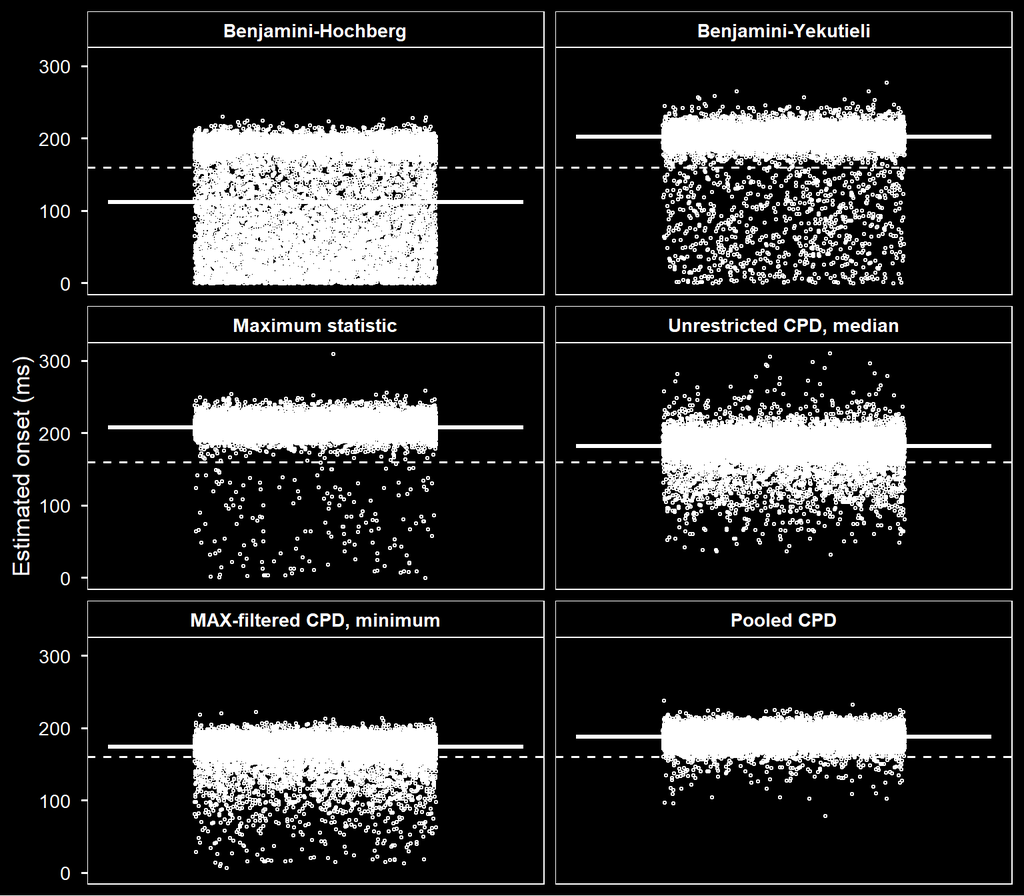

Figure 1: Sampling distributions for the six primary onset strategies. White horizontal bars mark medians and the dashed reference marks the true 160-ms onset.

```r
ggplot(primary_long, aes(x = 1, y = onset)) +
  geom_jitter(width = 0.16, size = 0.7, shape = 1, colour = "#ffffff") +
  stat_summary(fun = median, fun.min = median, fun.max = median,
               geom = "crossbar", width = 0.55, linewidth = 0.45, colour = "#ffffff") +
  geom_hline(yintercept = true_onset, linetype = "dashed", colour = "#ffffff", linewidth = 0.7) +
  facet_wrap(~strategy, ncol = 2) +
  scale_x_continuous(NULL, breaks = NULL) +
  labs(y = "Estimated onset (ms)") +
  theme_dark_bw() +
  theme(strip.text = element_text(colour = "#ffffff", face = "bold"))
```

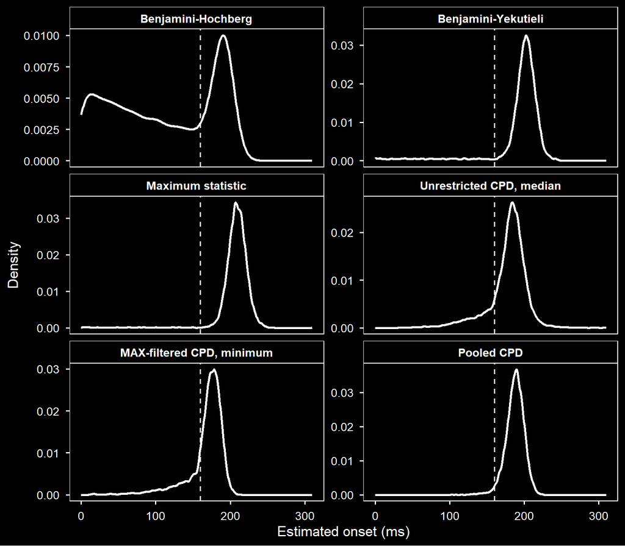

Figure 2: Density of estimated onsets for the six primary strategies. The dashed vertical line marks the true onset at 160 ms.

```r
primary_long |>
  filter(!is.na(onset)) |>
  ggplot(aes(x = onset)) +
  geom_density(colour = "#ffffff", fill = NA, linewidth = 0.9, adjust = 0.9) +
  geom_vline(xintercept = true_onset, linetype = "dashed",
             colour = "#ffffff", linewidth = 0.7) +
  facet_wrap(~strategy, scales = "free_y", ncol = 2) +
  labs(x = "Estimated onset (ms)", y = "Density") +
  theme_dark_bw()
```

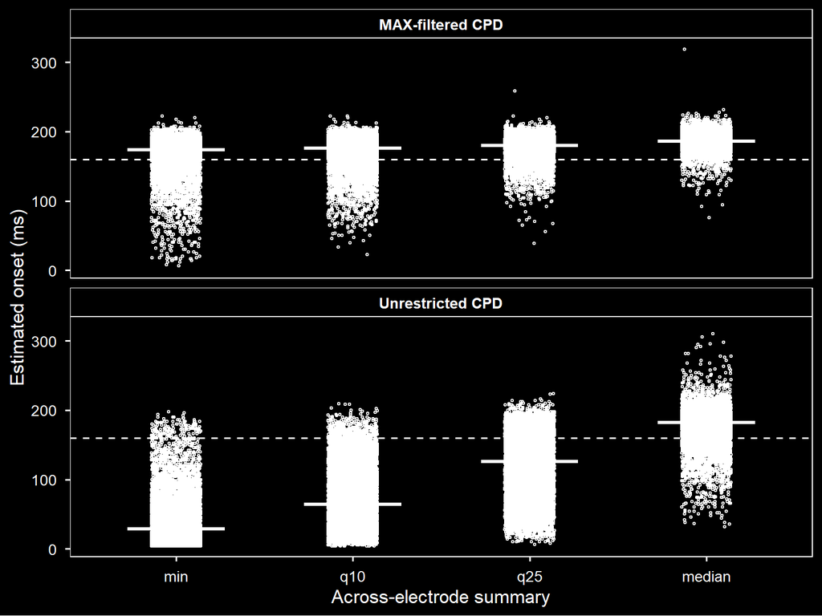

Figure 3: Change-point onset distributions under four across-electrode summaries. The panels separate unrestricted CPD from MAX-filtered CPD; the dashed reference marks the true 160-ms onset.

```r
cpd_four <- group_onset |>
  filter(Nt == 50,
         as.character(method) %in% c("CPD per electrode", "CPD if MAX significant"),
         as.character(summary) %in% summary_order) |>
  mutate(
    method = recode(as.character(method),
                    "CPD per electrode" = "Unrestricted CPD",
                    "CPD if MAX significant" = "MAX-filtered CPD"),
    summary = factor(as.character(summary), levels = summary_order)
  )

ggplot(cpd_four, aes(summary, onset)) +
  geom_jitter(width = 0.14, size = 0.65, shape = 1, colour = "#ffffff") +
  stat_summary(fun = median, fun.min = median, fun.max = median,
               geom = "crossbar", width = 0.55, linewidth = 0.45, colour = "#ffffff") +
  geom_hline(yintercept = true_onset, linetype = "dashed", colour = "#ffffff", linewidth = 0.7) +
  facet_wrap(~method, ncol = 1) +
  labs(x = "Across-electrode summary", y = "Estimated onset (ms)") +
  theme_dark_bw() +
  theme(strip.text = element_text(colour = "#ffffff", face = "bold"))
```

```r
quantile_grid <- seq(0.01, 0.99, by = 0.01)

cpd_quantiles <- perelec_all |>
  filter(Nt == 50,
         method %in% c("CPD per electrode", "CPD if MAX significant")) |>
  group_by(iter, method) |>
  summarise(onsets = list(onset[!is.na(onset)]), .groups = "drop") |>
  crossing(onsets_p = quantile_grid) |>
  mutate(onset_q = map2_dbl(onsets, onsets_p, ~{
    if(length(.x) == 0) NA_real_ else quantile(.x, .y, names = FALSE)
  })) |>
  group_by(method, onsets_p) |>
  summarise(
    median_onset = median(onset_q, na.rm = TRUE),
    median_bias = median_onset - true_onset,
    mae = mean(abs(onset_q - true_onset), na.rm = TRUE),
    .groups = "drop"
  ) |>
  mutate(method = recode(method,
                         "CPD per electrode" = "Unrestricted CPD",
                         "CPD if MAX significant" = "MAX-filtered CPD"))
```

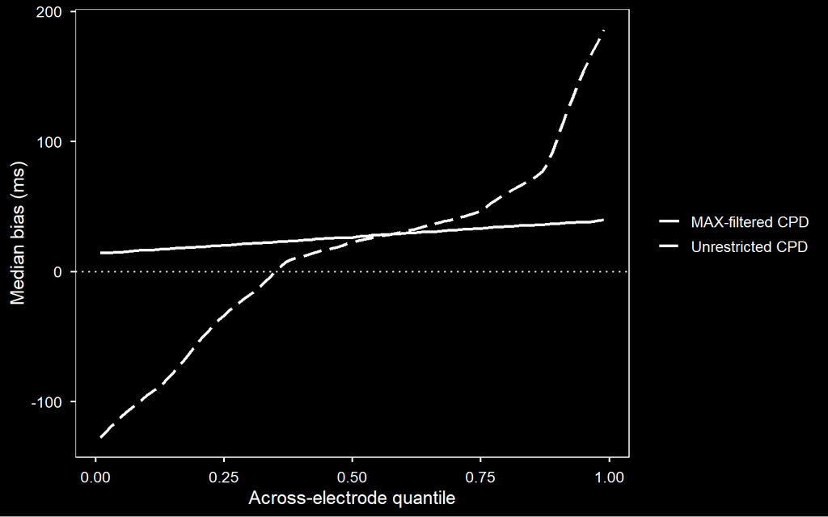

Figure 4: Quantile calibration for unrestricted and MAX-filtered CPD. The curves show median bias across montage quantiles; the horizontal reference at zero indicates an unbiased median onset.

```r
ggplot(cpd_quantiles, aes(onsets_p, median_bias, linetype = method)) +
  geom_line(linewidth = 0.9, colour = "#ffffff") +
  geom_hline(yintercept = 0, linetype = "dotted", colour = "#ffffff") +
  scale_linetype_manual(values = c("solid", "longdash")) +
  labs(x = "Across-electrode quantile", y = "Median bias (ms)", linetype = NULL) +
  theme_dark_bw()
```

### 5.3.1 Secondary check: the individual electrodes

The group onset is the quantity of interest, so the per-electrode view is kept below it rather than beside it. This diagnostic uses the separately generated 1,000-iteration, 50-trial dataset and retains all nine electrodes to show where early returned onsets arise.

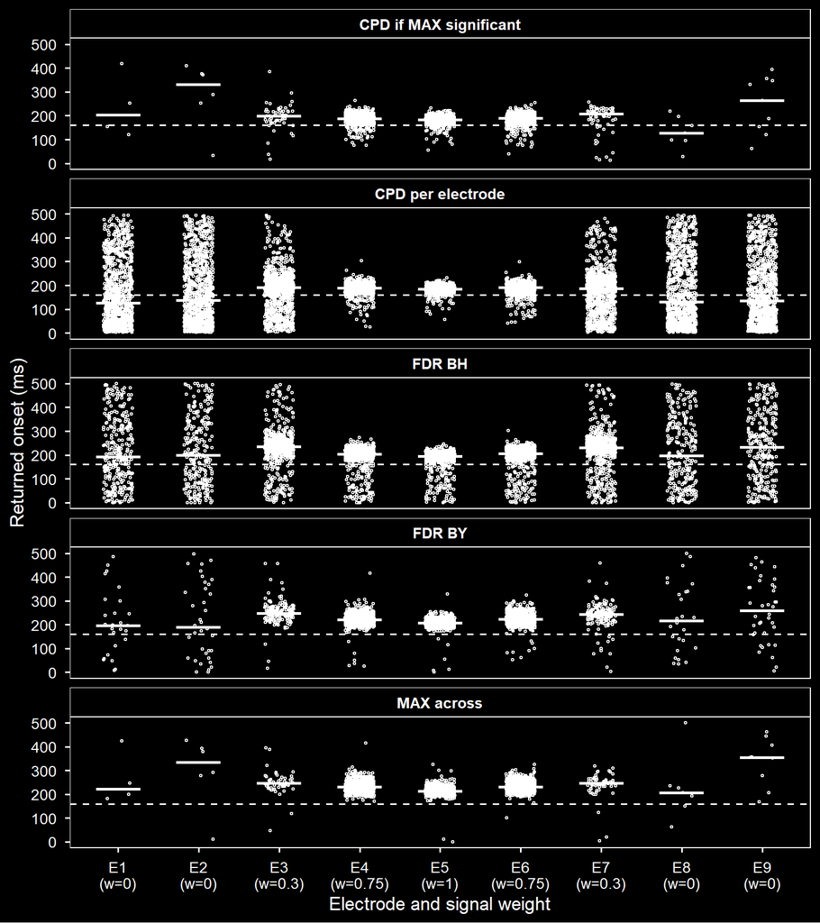

Figure 5: Electrode-wise onset distributions from the independent 1,000-iteration, 50-trial diagnostic run, retaining E1-E9 and their original weights. The 160-ms reference is a timing target only for positive-weight electrodes.

```r
electrode_levels <- paste0("E", 1:9)

diag_plot <- diag_pe |>
  filter(Nt == 50, method %in% elecwise_methods, !is.na(onset)) |>
  mutate(electrode = factor(electrode, levels = electrode_levels))

ggplot(diag_plot, aes(electrode, onset)) +
  geom_jitter(width = 0.18, size = 0.65, shape = 1, colour = "#ffffff") +
  stat_summary(fun = median, fun.min = median, fun.max = median,
               geom = "crossbar", width = 0.55, linewidth = 0.4, colour = "#ffffff") +
  geom_hline(yintercept = true_onset, linetype = "dashed", colour = "#ffffff", linewidth = 0.65) +
  facet_wrap(~method, ncol = 1) +
  scale_x_discrete(labels = paste0("E", 1:9, "\n(w=", w, ")")) +
  labs(x = "Electrode and signal weight", y = "Returned onset (ms)") +
  theme_dark_bw() +
  theme(strip.text = element_text(colour = "#ffffff", face = "bold"))
```

## 5.4 Observations

Both checks on the implementation pass. MAX across under the minimum summary and MAX virtual return an identical median of 208 ms, an identical spread of 21.5 ms and an identical bias, as they must, being the same operation. Within every method the four summaries are ordered upward from the minimum, as their definitions require.

The primary 10,000-iteration comparison is interpreted from the full table together with MAE, underestimation and no-onset rates rather than from bias alone. This matters because a strategy can have a small median bias while still producing a broad distribution with substantial early and late errors. The montage summary also changes the estimator: minimum-based summaries are especially sensitive to an early onset returned at any electrode, whereas more central summaries are less exposed to a single early excursion.

The mean absolute error complements median bias because errors in opposite directions cannot cancel. The distribution plots are therefore retained alongside the numerical summaries, particularly for Benjamini-Hochberg and change-point procedures, whose early tails can be scientifically important even when their central estimates appear less extreme. These qualitative features are consistent with the concerns raised by Rousselet (2025), while the present nine-electrode aggregation means that the exact bias and error values should be interpreted as properties of this simulation design rather than as a direct replication of the single-electrode results.

# 6 Independent 50-trial stability check

The 50-trial stratum in the separate trial-number dataset provides an independent 1,000-iteration check against the primary 10,000-iteration run. It is not used to replace the main analysis; it is used only to see whether the direction and approximate magnitude of the primary bias estimates are strongly dependent on one Monte Carlo realisation.

```r
size50_primary <- group_size |>
  filter(Nt == 50) |>
  inner_join(primary_spec, by = c("method", "summary")) |>
  mutate(strategy = factor(strategy, levels = primary_spec$strategy)) |>
  group_by(strategy) |>
  summarise(independent_bias = median(onset, na.rm = TRUE) - true_onset,
            .groups = "drop")

bias_stability <- primary_summary |>
  select(strategy, main_bias = bias) |>
  left_join(size50_primary, by = "strategy") |>
  mutate(absolute_difference = abs(main_bias - independent_bias),
         across(c(main_bias, independent_bias, absolute_difference), ~round(.x, 1)))
```

```r
bias_stability |>
  rename(Method = strategy,
         `Main bias (ms)` = main_bias,
         `Independent bias (ms)` = independent_bias,
         `Absolute difference (ms)` = absolute_difference) |>
  knitr::kable()
```

Table 6: Bias in the 10,000-iteration main simulation and the independently generated 1,000-iteration 50-trial stratum from the trial-number sensitivity run.

| Method | Main bias (ms) | Independent bias (ms) | Absolute difference (ms) |
| --- | --- | --- | --- |
| Benjamini-Hochberg | -48 | -40 | 8 |
| Benjamini-Yekutieli | 42 | 42 | 0 |
| Maximum statistic | 48 | 50 | 2 |
| Unrestricted CPD, median | 22 | 22 | 0 |
| MAX-filtered CPD, minimum | 14 | 12 | 2 |
| Pooled CPD | 28 | 28 | 0 |

Agreement here is descriptive rather than a formal replication test. The larger 10,000-iteration estimates remain the primary results.

# 7 Trial-number sensitivity

## 7.1 Description

The third independently generated dataset contains 1,000 simulations at 25, 50, 75 and 100 trials per condition. The same six primary strategies are evaluated at every sample size. Trial number is varied empirically rather than assuming that more trials will improve every montage-level estimator in the same way.

A simple expectation would be that more trials make every onset estimate more accurate. The saved results allow that expectation to be checked rather than built into the interpretation. For minimum-based procedures, increased sensitivity can also change which electrodes contribute the earliest retained location, so improved signal estimation need not translate monotonically into improved montage-level onset.

```r
size_primary <- group_size |>
  inner_join(primary_spec, by = c("method", "summary")) |>
  mutate(strategy = factor(strategy, levels = primary_spec$strategy))

size_summary <- size_primary |>
  group_by(Nt, strategy) |>
  summarise(median_onset = median(onset, na.rm = TRUE),
            bias = median_onset - true_onset,
            mae = mean(abs(onset - true_onset), na.rm = TRUE),
            sd = sd(onset, na.rm = TRUE),
            underestimation = 100 * mean(onset < true_onset, na.rm = TRUE),
            no_onset = 100 * mean(is.na(onset)),
            .groups = "drop") |>
  mutate(across(c(median_onset, bias, mae, sd, underestimation, no_onset), ~round(.x, 1)))
```

```r
size_summary |>
  rename(`Trials per condition` = Nt,
         Method = strategy,
         `Median onset (ms)` = median_onset,
         `Median bias (ms)` = bias,
         `MAE (ms)` = mae,
         `SD (ms)` = sd,
         `Underestimation (%)` = underestimation,
         `No onset (%)` = no_onset) |>
  knitr::kable()
```

Table 7: Sensitivity of the six primary strategies to trial number. Each trial count is based on 1,000 independently generated simulations.

| Trials per condition | Method | Median onset (ms) | Median bias (ms) | MAE (ms) | SD (ms) | Underestimation (%) | No onset (%) |
| --- | --- | --- | --- | --- | --- | --- | --- |
| 25 | Benjamini-Hochberg | 200 | 40 | 62.0 | 69.9 | 28.8 | 5.6 |
| 25 | Benjamini-Yekutieli | 230 | 70 | 72.8 | 34.5 | 1.9 | 35.6 |
| 25 | Maximum statistic | 230 | 70 | 73.5 | 33.5 | 2.0 | 7.2 |
| 25 | Unrestricted CPD, median | 182 | 22 | 31.0 | 33.4 | 23.3 | 0.0 |
| 25 | MAX-filtered CPD, minimum | 186 | 26 | 31.2 | 33.0 | 15.2 | 7.2 |
| 25 | Pooled CPD | 194 | 34 | 34.4 | 23.8 | 7.3 | 0.0 |
| 50 | Benjamini-Hochberg | 120 | -40 | 69.0 | 70.6 | 61.4 | 0.0 |
| 50 | Benjamini-Yekutieli | 202 | 42 | 45.6 | 37.5 | 7.9 | 0.1 |
| 50 | Maximum statistic | 210 | 50 | 50.3 | 22.0 | 1.6 | 0.0 |
| 50 | Unrestricted CPD, median | 182 | 22 | 27.1 | 27.5 | 16.4 | 0.0 |
| 50 | MAX-filtered CPD, minimum | 172 | 12 | 19.9 | 25.3 | 23.5 | 0.0 |
| 50 | Pooled CPD | 188 | 28 | 27.4 | 12.7 | 2.1 | 0.0 |
| 75 | Benjamini-Hochberg | 86 | -74 | 78.2 | 66.3 | 73.7 | 0.0 |
| 75 | Benjamini-Yekutieli | 192 | 32 | 39.6 | 43.1 | 12.5 | 0.0 |
| 75 | Maximum statistic | 200 | 40 | 41.4 | 21.8 | 2.3 | 0.0 |
| 75 | Unrestricted CPD, median | 182 | 22 | 24.7 | 21.9 | 10.6 | 0.0 |
| 75 | MAX-filtered CPD, minimum | 172 | 12 | 18.2 | 24.5 | 21.0 | 0.0 |
| 75 | Pooled CPD | 184 | 24 | 24.2 | 10.3 | 1.5 | 0.0 |
| 100 | Benjamini-Hochberg | 78 | -82 | 80.9 | 65.7 | 74.5 | 0.0 |
| 100 | Benjamini-Yekutieli | 186 | 26 | 37.0 | 45.2 | 14.6 | 0.0 |
| 100 | Maximum statistic | 196 | 36 | 36.7 | 21.4 | 2.6 | 0.0 |
| 100 | Unrestricted CPD, median | 180 | 20 | 22.6 | 19.5 | 9.3 | 0.0 |
| 100 | MAX-filtered CPD, minimum | 170 | 10 | 16.4 | 22.9 | 20.5 | 0.0 |
| 100 | Pooled CPD | 182 | 22 | 21.6 | 8.6 | 1.1 | 0.0 |

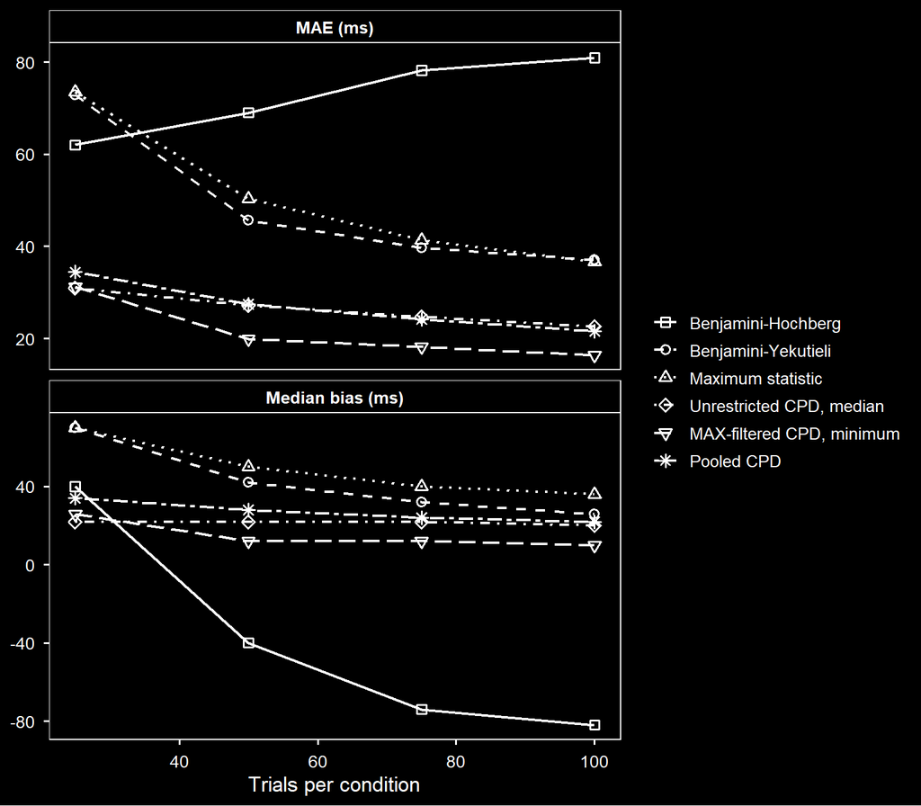

Figure 6: Trial-number sensitivity for the six primary strategies. Median bias and MAE are shown across 25, 50, 75 and 100 trials per condition.

```r
size_plot <- size_summary |>
  select(Nt, strategy, bias, mae) |>
  pivot_longer(c(bias, mae), names_to = "metric", values_to = "value") |>
  mutate(metric = recode(metric,
                         bias = "Median bias (ms)",
                         mae = "MAE (ms)"))

ggplot(size_plot, aes(Nt, value, linetype = strategy, shape = strategy, group = strategy)) +
  geom_line(linewidth = 0.8, colour = "#ffffff") +
  geom_point(size = 2.2, stroke = 0.8, colour = "#ffffff") +
  facet_wrap(~metric, ncol = 1, scales = "free_y") +
  scale_linetype_manual(values = c("solid", "dashed", "dotted", "dotdash", "longdash", "twodash")) +
  scale_shape_manual(values = c(0, 1, 2, 5, 6, 8)) +
  labs(x = "Trials per condition", y = NULL, linetype = NULL, shape = NULL) +
  theme_dark_bw() +
  theme(strip.text = element_text(colour = "#ffffff", face = "bold"))
```

The effect of trial number is method-dependent. Changes in sample size alter both the probability of returning an onset and the distribution of returned times. Underestimation and no-onset rates are retained in the table because median bias and MAE alone do not show whether a distribution contains a substantial early component or whether a procedure often fails to return an onset.

# 8 Discussion and next steps

This notebook implements seven onset methods. Where a correction is applied it spans the whole electrode-by-time search space; the two plain change-point methods apply none, which is itself one of the findings. For the five electrode-wise methods the onsets are saved at all nine electrodes and summarised afterwards, outside the simulation loop, so the group onset is a reporting choice rather than something baked into the code:

- FDR: Benjamini-Hochberg (BH) and Benjamini-Yekutieli (BY) across electrodes.
- MAX permutation correction: one threshold across all electrodes, and the same threshold on a virtual electrode, the maximum squared t across electrodes (Jaworska et al., 2020, as cited in Rousselet, 2025).
- change point at every electrode, change point restricted to the electrodes found significant by the MAX correction, and change point on the virtual electrode.

Each of the five electrode-wise methods is reported under four summaries across electrodes, the minimum, the 10th and 25th percentiles, and the median. That gives twenty strategies, and twenty-two once the two virtual-electrode methods are added. Reporting the same set of summaries for every method is deliberate: it prevents the comparison from turning on which summary happens to suit which method.

One consequence constrains how the results should be read: MAX across and MAX virtual are not two methods but one. Both compare the same squared t values against the same threshold, and the earliest electrode to cross it is by definition the first time point at which the maximum across electrodes crosses it, so under the minimum summary the two return an identical group onset in every run. Nothing in the data can separate them. Under the median and the quantiles the numbers differ, but only because those summaries describe a spread across electrodes that the virtual electrode discards by construction. Both are retained because the across-electrode version also yields per-electrode onsets for the sanity check, and because their agreement under the minimum is a check on the implementation.

The change-point methods are a different case, and are distinct from one another. Change point detection is not a pointwise threshold, so applying it to each electrode and taking the earliest result is not the same operation as applying it to the maximum-across-electrodes curve. The maximum curve is a series in its own right, with its own variance structure, and the change point found in it need not coincide with any change point found in the individual electrodes. Any difference between them in the results is real and worth interpreting, as is the difference between the unrestricted and the restricted per-electrode versions, which share their onsets and differ only in which electrodes are allowed to report one.

## 8.1 Choosing which electrodes to trust

Taking the earliest onset across every electrode is the most faithful reading of the question the experiment asks, but it hands the result to whichever electrode errs earliest, and four of the nine contain nothing but noise. Restricting the summary to the signal electrodes is not available, for the reason set out with the method above. Four other routes exist, three of which are already implemented here; all four are developed in the report.

- **Regions of interest.** In applied work the electrodes showing a given component are often known from previous studies and declared before analysis. That constraint is legitimate because it comes from outside the dataset in hand, and it is unavailable here, since the simulation has no literature behind it. The pessimistic results for the minimum summary are therefore a worst case.
- **Selection by a corrected test**, implemented above as change point restricted to MAX-significant electrodes, at the cost of selecting and estimating on the same data.
- **A different summary** rather than a different electrode set, implemented as the minimum, two lower quantiles and the median. Which one to prefer is a calibration question, settled against a known truth rather than by argument (Rousselet, 2025).
- **The change-point penalty.** The MBIC penalty (Zhang & Siegmund, 2007), a minimum segment length of two and two expected change points reproduce the settings of Rousselet (2025), which keeps the results comparable with that paper. The same paper notes that change point detection could be better calibrated (Truong et al., 2020, as cited in Rousselet, 2025). A stricter penalty should trade false onsets on noise-only electrodes against sensitivity to weak real effects, and the penalty is set in one place so that this can be tested by editing a single line.

Next steps.

One further possibility does not follow from these results but from the difference figure in `build.notebook.qmd`: a generator in which the effect alters the variability of the data and not only its mean. The additive template used here cannot produce that, and it is the case in which a distribution-based onset measure would have something to find.

A note on assumptions. Averaging across trials treats the trials as independent. That is the standard assumption, but it does not strictly hold. The response on one trial depends on the previous one through neuronal adaptation, changing reaction times, shifts in anticipation or strategy, and fatigue. In this simulation the trials are independent by construction, so the assumption is safe here, but it is worth stating as a limitation for real data, where time-series models would be needed to capture the dependence.

# 9 References

- Benjamini, Y., & Hochberg, Y. (1995). Controlling the false discovery rate: A practical and powerful approach to multiple testing. *Journal of the Royal Statistical Society: Series B, 57*(1), 289-300. https://doi.org/10.1111/j.2517-6161.1995.tb02031.x
- Benjamini, Y., & Yekutieli, D. (2001). The control of the false discovery rate in multiple testing under dependency. *The Annals of Statistics, 29*(4), 1165-1188. https://doi.org/10.1214/aos/1013699998
- Edwards, A. W. F., & Cavalli-Sforza, L. L. (1965). A method for cluster analysis. *Biometrics, 21*, 362-375.
- Killick, R., & Eckley, I. A. (2014). changepoint: An R package for changepoint analysis. *Journal of Statistical Software, 58*(3), 1-19. https://doi.org/10.18637/jss.v058.i03
- Kriegeskorte, N., Simmons, W. K., Bellgowan, P. S. F., & Baker, C. I. (2009). Circular analysis in systems neuroscience: The dangers of double dipping. *Nature Neuroscience, 12*(5), 535-540. https://doi.org/10.1038/nn.2303
- Koehler, E., Brown, E., & Haneuse, S. J.-P. A. (2009). On the assessment of Monte Carlo error in simulation-based statistical analyses. *The American Statistician, 63*(2), 155-162. https://doi.org/10.1198/tast.2009.0030
- Luck, S. J. (2014). *An introduction to the event-related potential technique* (2nd ed.). MIT Press.
- Rousselet, G. A. (2025). Using cluster-based permutation tests to estimate MEG/EEG onsets: How bad is it? *European Journal of Neuroscience, 61*(1), e16618. https://doi.org/10.1111/ejn.16618
- Scott, A. J., & Knott, M. (1974). A cluster analysis method for grouping means in the analysis of variance. *Biometrics, 30*(3), 507-512.
- Zhang, N. R., & Siegmund, D. O. (2007). A modified Bayes information criterion with applications to the analysis of comparative genomic hybridization data. *Biometrics, 63*(1), 22-32. https://doi.org/10.1111/j.1541-0420.2006.00662.x